# Healthcare Intel Digest

**Week of September 14, 2026**Market data through: September 11, 2026Narrative created: September 14, 2026

Weekly review of healthcare services, technology, distribution, and diagnostic company performance, changes, earnings activity, and strategy narrative.

## In the News

### Executive View

- **Preliminary 2027 Medicare Advantage designs broaden the retrenchment beyond Aetna’s distribution controls.** Broker intelligence indicates benefit reductions at UnitedHealthcare and Humana, plan removals and possible enrollment caps. The final CMS landscape remains the necessary confirmation.
- **CMS identified a cross-channel payment-integrity gap:** four suppliers revoked from Original Medicare subsequently billed MA plans. Fraud controls increasingly need to follow entities across fee-for-service, MA and Part D rather than operate within separate claims systems.
- **Coverage pressure is beginning to affect provider utilization, not merely payer mix.** HCA management attributed a material decline in elective surgery partly to ACA members becoming uninsured and cost-sensitive patients deferring care.
- **Administrative data remains a regulatory liability.** A fourth state Medicaid audit found that authorization and appeal data could not support required behavioral-health parity analyses, increasing the value of auditable decision-lifecycle infrastructure.
- **Overall environment: deteriorated for MA benefits, provider elective volume and utilization-management compliance; improved for payment-integrity and authorization-data demand.**

### 1. Preliminary plan designs point to broader 2027 MA benefit retrenchment

**Status:** UPDATE

**What happened**

Last month’s Aetna commission changes indicated a selective enrollment throttle. This week, broker-based intelligence suggested that the pullback is broader: UnitedHealthcare reportedly removed approximately 13% of plans offered across 18 states, while Humana’s designs generated negative broker feedback because of less-generous benefits. Reported changes include reduced Part B givebacks and dental benefits, higher specialist copays and, for some products, possible enrollment caps. UnitedHealthcare and Humana declined to confirm the details, and CMS has not yet released the final 2027 landscape. [Axios, “Medicare Advantage Plans Appear to Be Cutting Benefits in 2027,” September 10, 2026](https://www.axios.com/2026/09/10/medicare-advantage-benefit-cuts-2027). ([axios.com](https://www.axios.com/2026/09/10/medicare-advantage-benefit-cuts-2027))

**Implication**

The new information changes the prior view from carrier-specific growth management to probable industry-wide benefit normalization. If confirmed, reduced benefits and narrower product availability should support plan margin restoration in 2027, but at the expense of membership retention, broker satisfaction and consumer affordability.

Supplemental-benefit vendors face volume and pricing pressure, while brokers, navigation platforms and provider access centers should see more plan-comparison and network-verification activity. Providers may experience additional contract disruption if plans pair benefit reductions with narrower networks. Confidence is moderate because the evidence is preliminary rather than finalized CMS plan data.

**Watch next**

The CMS MA and Part D landscape, including county exits, plan counts, premiums, benefit structures and disclosed enrollment limits.

### 2. CMS’s $3.4 billion DME action exposes fraud migration from Original Medicare into MA

**Status:** UPDATE

**What happened**

CMS barred 11 DMEPOS suppliers from receiving future MA and Part D payments after identifying more than $3.4 billion in suspected fraudulent billing during 2025 and 2026. The suppliers allegedly billed for deceased beneficiaries, unordered equipment and services never furnished. Four had already been revoked from Original Medicare and subsequently began billing MA plans. CMS added the suppliers to its Preclusion List; the $3.4 billion represents suspected billing, not a disclosed paid-loss or recovery amount. [CMS, “CMS Cracks Down on Massive $3.4 Billion Medical Equipment Supplier Fraud Scheme,” September 8, 2026](https://www.cms.gov/newsroom/press-releases/cms-cracks-down-massive-3-4-billion-medical-equipment-supplier-fraud-scheme). ([cms.gov](https://www.cms.gov/newsroom/press-releases/cms-cracks-down-massive-3-4-billion-medical-equipment-supplier-fraud-scheme))

**Implication**

This materially extends the prior thesis that CMS is moving payment integrity toward prepayment intervention. The new finding is that enforcement in one payment channel can displace suspect billing into another unless supplier identity, ownership, death records, complaints and billing anomalies are monitored across the Medicare enterprise.

MA and Part D sponsors need near-real-time synchronization with CMS enrollment and preclusion actions, plus controls that identify abrupt billing by newly active or previously sanctioned entities. The opportunity favors payment-integrity platforms that combine entity resolution, external reference data and payment intervention—not isolated post-pay algorithms. Plans also face potential retrospective review costs, although reliable public data on amounts actually paid are unavailable.

**Watch next**

Whether CMS directs sponsors to review historical claims from the 11 suppliers, discloses paid-versus-stopped amounts or expands cross-program screening to related owners, ordering clinicians and telemarketing networks.

### 3. HCA’s elective-volume weakness suggests coverage loss is reaching provider revenue

**Status:** NEW

**What happened**

At a September 9 investor conference, HCA CEO Sam Hazen reportedly said elective surgical volumes fell 6% during the first half of 2026—approximately three times the prior-year decline. Management attributed the weakness primarily to ACA exchange members losing coverage and becoming uninsured, alongside patients delaying care for affordability reasons. HCA was not assuming a rebound before the customary fourth-quarter increase associated with deductible accumulation. These are company observations, not a national utilization measure. [American Health Intel, “The Ledger: HCA, Tenet and Community Health Diverge on 2026 Outlook,” September 10, 2026](https://americanhealthintel.com/editions/2026-09-10-ledger/). ([americanhealthintel.com](https://americanhealthintel.com/editions/2026-09-10-ledger/))

**Implication**

This weakens the assumption that coverage disruption merely reallocates patients among insurers. At least for one scaled hospital operator, some churn is transmitting into deferred procedures and uninsured status, affecting volume, revenue-cycle yield and potentially bad debt.

The near-term exposure is greatest for elective service lines and markets with high exchange penetration. It raises the value of eligibility surveillance, financial-clearance tools and patient-payment workflows, but technology cannot fully offset lost insured demand. If the pattern persists beyond HCA, providers will need tighter capacity planning and more conservative assumptions about commercially insured procedural recovery.

**Watch next**

HCA’s third-quarter payer mix, surgical volume and self-pay trends, and whether other hospital systems attribute utilization softness to coverage loss rather than site-of-care migration.

### 4. Medicaid parity audits are revealing authorization-data failures, not just policy violations

**Status:** NEW

**What happened**

HHS-OIG found that South Carolina did not ensure that three selected Medicaid MCOs—covering approximately 80% of the state’s managed-care enrollment—complied with mental-health and substance-use-disorder parity requirements for prior authorization. All three lacked accurate and complete authorization data, none produced reports reconciling to underlying records, and two remained noncompliant more than six years after the October 2017 deadline. In one example, an MCO continued to classify 169 of 822 requests as denied after they had been approved and paid following review or appeal. [HHS-OIG, “South Carolina Did Not Ensure That Selected Medicaid Managed Care Organizations Complied With Mental Health and Substance Use Disorder Parity Requirements Related to Prior Authorization,” September 2026](https://oig.hhs.gov/documents/audit/11877/A-04-24-07115.pdf). ([oig.hhs.gov](https://oig.hhs.gov/documents/audit/11877/A-04-24-07115.pdf))

**Implication**

Because South Carolina is the fourth state in the OIG series with similar findings, the risk increasingly appears structural. MCO authorization systems often record the initial decision but cannot reliably reconstruct re-review, appeal, payment and benefit-classification outcomes.

That creates exposure beyond parity compliance. The same data lineage will support CMS prior-authorization reporting, denial explanations and 2027 API workflows. Plans and states therefore need auditable authorization records that preserve status changes and contractor actions, while vendors unable to reconcile authorization and claims data face displacement risk.

**Watch next**

Corrective-action requirements in South Carolina and whether CMS converts the multi-state findings into standardized Medicaid authorization-data specifications or contract oversight.

### 5. Oracle’s agentic EHR changes its product ambition, not its execution burden

**Status:** UPDATE

**What happened**

One week after congressional and GAO scrutiny reinforced Oracle Health’s VA execution risk, Oracle described a new health-management and EHR system built around specialty-specific AI agents, characterizing it as a “100% agentic” architecture. The announcement accompanied a strong corporate quarter, but Oracle did not disclose Oracle Health revenue, customer adoption, implementation timelines or reference deployments for the new system. [Oracle, “Oracle Announces Q1 Results Driven by Triple Digit Growth in Cloud Infrastructure Revenues,” September 10, 2026](https://www.oracle.com/news/announcement/q1fy27-earnings-release-2026-09-10/). ([oracle.com](https://www.oracle.com/news/announcement/q1fy27-earnings-release-2026-09-10/?utm_source=openai))

**Implication**

The product direction is consequential: Oracle is positioning AI as the workflow and decision layer of the core EHR rather than as an ambient-documentation add-on. If functional, that could compress implementation work and shift clinician labor toward exception management.

However, the announcement does not refute last week’s execution thesis. An agent-native platform increases the importance of clinical validation, governance, workflow configuration and human oversight. For health systems, independent evidence on deployment speed and reliability matters more than Oracle’s architecture description.

**Watch next**

Named production customers, migration terms for existing Millennium users, specialty-level performance evidence and whether agentic tooling measurably shortens implementations.

### What I'm Watching Next

- **September 15, 2026:** The second CMS preview period for preliminary 2027 Medicare Part C and Part D Star Ratings closes. Material plan disclosures could provide the first company-level evidence on 2028 quality-bonus economics. [MHK, “CMS Opens Second Preview of 2027 Medicare Star Ratings,” September 10, 2026](https://mhk.com/resource/compliance-pulse/2027-medicare-star-ratings-second-preview/). ([mhk.com](https://mhk.com/resource/compliance-pulse/2027-medicare-star-ratings-second-preview/?utm_source=openai))

### Bottom Line

The most important weekly change is the emerging breadth of 2027 MA benefit retrenchment: margin repair increasingly appears likely to come through benefit, product and distribution changes rather than medical-cost improvement alone. MA plan-design and enrollment exposure requires the closest attention. The September 15 Stars preview deadline is the next confirmed catalyst most likely to produce plan-specific information that changes the view.

## Notable Changes

Comparison with the final report dated September 7, 2026 (market data through September 4, 2026).

### Sectors

#### Top-three comparison

| Entity | Previous | Current | Change | Current return |
| --- | --- | --- | --- | --- |
| Precision Diagnostics | #1 | #1 | — 0 | +92.2% |
| Inpatient Non-Acute Providers | #2 | #2 | — 0 | +85.8% |
| Value-Based Care | #3 | #3 | — 0 | +67.6% |

### Stocks

#### Top-three comparison

| Entity | Previous | Current | Change | Current return |
| --- | --- | --- | --- | --- |
| 10x Genomics (TXG) | #1 | #1 | — 0 | +442.6% |
| PACS Group (PACS) | #2 | #2 | — 0 | +359.1% |
| Agilon Health (AGL) | #3 | #3 | — 0 | +235.6% |

#### Largest rank changes

| Entity | Previous | Current | Change | Current return |
| --- | --- | --- | --- | --- |
| Humana (HUM) | #27 | #19 | ↑ 8 | +48.2% |
| Acadia Healthcare (ACHC) | #34 | #26 | ↑ 8 | +30.5% |
| UnitedHealth (UNH) | #33 | #43 | ↓ 10 | +7.5% |

### Subcategory movement since the previous report

| Subcategory | Move | Last Report, 12m Ret | Current Report, 12m Ret |
| --- | --- | --- | --- |
| Health System Providers | +4.1% | +2.1% | +9.2% |
| Inpatient Non-Acute Providers | +1.9% | +64.9% | +85.8% |
| Digital Health, Specialty, Benefits | -0.2% | +2.0% | +1.5% |
| Health Care Real Estate | -0.4% | +33.5% | +32.0% |
| Value-Based Care | -0.6% | +56.1% | +67.6% |
| Outpatient and Home Providers | -1.2% | +46.2% | +42.0% |
| Payers | -2.3% | +28.8% | +19.1% |
| Precision Diagnostics | -2.4% | +88.7% | +92.2% |
| Pharma Distribution | -3.4% | +34.8% | +26.6% |
| Health IT and Data | -5.0% | -21.8% | -36.0% |

### Largest company moves

| Direction | Company | Ticker | Move |
| --- | --- | --- | --- |
| Gain | Clover Health | CLOV | +13.3% |
| Gain | 10x Genomics | TXG | +9.5% |
| Gain | Progyny | PGNY | +5.4% |
| Decline | QuidelOrtho | QDEL | -15.7% |
| Decline | Omada Health | OMDA | -13.7% |
| Decline | P3 Health | PIII | -9.8% |

## Subcategory Performance

| Subcategory | Companies | Market cap | 3m Return | 12m Return | 24m Return |
| --- | --- | --- | --- | --- | --- |
| Payers | 10 | $769.8B | -4.4% | +19.1% | -10.2% |
| Health System Providers | 5 | $119.8B | +18.0% | +9.2% | +13.8% |
| Inpatient Non-Acute Providers | 4 | $31.4B | +19.2% | +85.8% | +12.0% |
| Health Care Real Estate | 8 | $266.4B | +7.5% | +32.0% | +59.8% |
| Value-Based Care | 5 | $7.2B | -12.4% | +67.6% | -8.2% |
| Outpatient and Home Providers | 11 | $64.8B | +5.9% | +42.0% | +72.1% |
| Digital Health, Specialty, Benefits | 10 | $26.3B | +8.6% | +1.5% | +36.7% |
| Health IT and Data | 12 | $470.6B | -5.7% | -36.0% | -3.3% |
| Pharma Distribution | 5 | $222.6B | +10.6% | +26.6% | +67.0% |
| Precision Diagnostics | 12 | $168.6B | +32.4% | +92.2% | +137.4% |

Subcategory returns use the most recently saved market capitalizations as weights.

## Stock Performance vs. SPY

The same selected stocks appear in every chart. Each line is labeled at the right with its ticker and return for the displayed window.

### Last 6 months

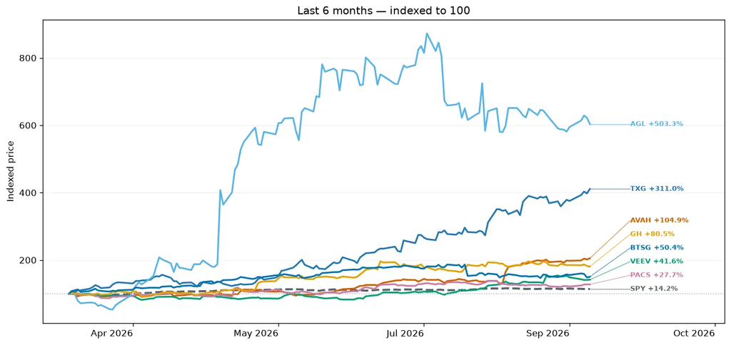

### Last 12 months

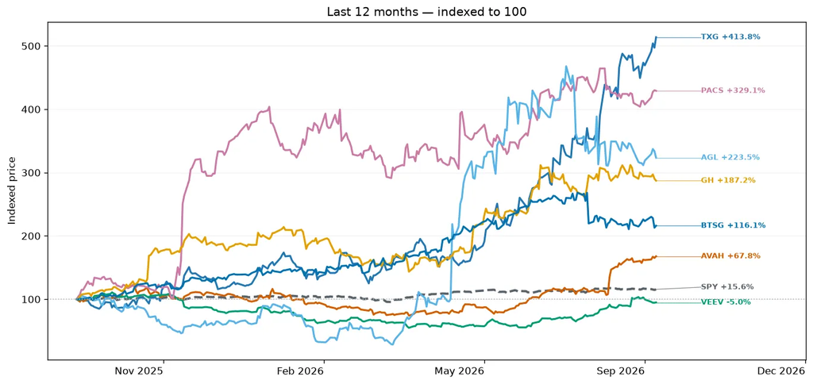

### Last 24 months

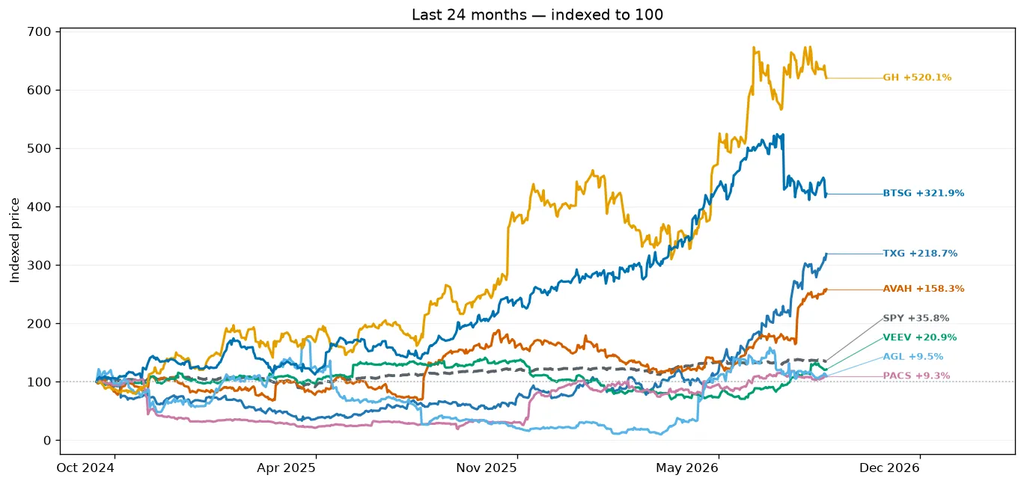

## Current Top Stocks

### Last 3 months

| Rank | Company | Ticker | Market cap | Return |
| --- | --- | --- | --- | --- |
| 1 | 10x Genomics | TXG | $6.1B | +137.8% |
| 2 | Aveanna Healthcare | AVAH | $2.0B | +98.6% |
| 3 | Veeva Systems | VEEV | $33.1B | +64.5% |
| 4 | NeoGenomics | NEO | $2.1B | +55.3% |
| 5 | Natera | NTRA | $39.4B | +55.1% |

### Last 12 months

| Rank | Company | Ticker | Market cap | Return |
| --- | --- | --- | --- | --- |
| 1 | 10x Genomics | TXG | $6.1B | +442.6% |
| 2 | PACS Group | PACS | $7.3B | +359.1% |
| 3 | Agilon Health | AGL | $2.1B | +235.6% |
| 4 | Guardant Health | GH | $21.4B | +186.7% |
| 5 | Lifestance Health | LFST | $4.0B | +148.0% |

### Last 24 months

| Rank | Company | Ticker | Market cap | Return |
| --- | --- | --- | --- | --- |
| 1 | Guardant Health | GH | $21.4B | +487.5% |
| 2 | BrightSpring Health Services | BTSG | $12.4B | +324.0% |
| 3 | 10x Genomics | TXG | $6.1B | +206.6% |
| 4 | Talkspace | TALK | $874.4M | +167.9% |
| 5 | Aveanna Healthcare | AVAH | $2.0B | +161.2% |

## Companies by Subcategory

### PayersLast 3m: -4.4%

| Company | Ticker | Market cap | 3m Return | 12m Return | 24m Return |
| --- | --- | --- | --- | --- | --- |
| UnitedHealth | UNH | $380.1B | -7.2% | +7.5% | -36.2% |
| CVS Health | CVS | $135.1B | -7.2% | +26.2% | +63.3% |
| Humana | HUM | $43.7B | +8.1% | +48.2% | +27.4% |
| Oscar Health | OSCR | $9.4B | +16.0% | +69.5% | +51.6% |
| Molina Healthcare | MOH | $10.2B | +2.0% | +12.9% | -43.0% |
| Cigna | CI | $73.7B | -5.8% | -7.3% | -23.0% |
| Elevance | ELV | $81.5B | +3.6% | +34.3% | -24.0% |
| Clover Health | CLOV | $2.2B | +1.9% | +57.5% | +61.2% |
| Centene | CNC | $30.7B | +1.9% | +99.7% | -11.9% |
| Alignment Health | ALHC | $3.1B | -36.2% | -21.4% | +6.1% |

### Health System ProvidersLast 3m: +18.0%

| Company | Ticker | Market cap | 3m Return | 12m Return | 24m Return |
| --- | --- | --- | --- | --- | --- |
| HCA Healthcare | HCA | $87.2B | +10.3% | +5.4% | +8.2% |
| Tenet Health | THC | $20.5B | +51.0% | +36.8% | +62.4% |
| Universal Health Services | UHS | $10.2B | +19.4% | -8.8% | -24.8% |
| Community Health Systems | CYH | $417.4M | -6.4% | -0.7% | -49.0% |
| Ardent Health Partners | ARDT | $1.5B | +17.4% | -16.1% | -39.5% |

### Inpatient Non-Acute ProvidersLast 3m: +19.2%

| Company | Ticker | Market cap | 3m Return | 12m Return | 24m Return |
| --- | --- | --- | --- | --- | --- |
| The Ensign Group | ENSG | $10.4B | +16.5% | +3.6% | +13.9% |
| Acadia Healthcare | ACHC | $2.8B | +15.3% | +30.5% | -63.7% |
| Encompass Health | EHC | $11.0B | +19.9% | -3.4% | +30.5% |
| PACS Group | PACS | $7.3B | +23.4% | +359.1% | +9.9% |

### Health Care Real EstateLast 3m: +7.5%

| Company | Ticker | Market cap | 3m Return | 12m Return | 24m Return |
| --- | --- | --- | --- | --- | --- |
| Healthpeak properties | DOC | $15.1B | -1.9% | +12.3% | -10.1% |
| Ventas, Inc | VTR | $48.0B | +6.4% | +29.1% | +38.3% |
| Medical Properties Trust | MPT | $2.8B | -26.6% | — | — |
| National Health Investors | NHI | $3.7B | -2.5% | -10.2% | -17.3% |
| Omega Healthcare Investors | OHI | $15.1B | +2.7% | +10.6% | +15.7% |
| Welltower | WELL | $166.9B | +10.0% | +39.3% | +81.6% |
| CareTrust REIT | CTRE | $9.6B | +4.8% | +12.9% | +24.3% |
| Sabra Health Care REIT | SBRA | $5.3B | +9.6% | +7.7% | +10.4% |

### Value-Based CareLast 3m: -12.4%

| Company | Ticker | Market cap | 3m Return | 12m Return | 24m Return |
| --- | --- | --- | --- | --- | --- |
| Privia Health Group | PRVA | $3.0B | -12.8% | -10.4% | +7.8% |
| Astrana Health | ASTH | $1.8B | -1.7% | +27.3% | -30.3% |
| Agilon Health | AGL | $2.1B | -20.5% | +235.6% | +1.7% |
| Evolent Health | EVH | $347.6M | -12.7% | -53.5% | -86.1% |
| P3 Health | PIII | $32.7M | -31.1% | -2.0% | -65.8% |

### Outpatient and Home ProvidersLast 3m: +5.9%

| Company | Ticker | Market cap | 3m Return | 12m Return | 24m Return |
| --- | --- | --- | --- | --- | --- |
| Davita | DVA | $15.4B | -13.0% | +36.3% | +11.0% |
| Fresenius | FMS | $13.8B | -2.9% | -10.5% | +6.0% |
| Surgery Partners | SGRY | $2.0B | -6.1% | -34.2% | -53.6% |
| Option Care Health | OPCH | $3.4B | +13.1% | -17.6% | -26.6% |
| Lifestance Health | LFST | $4.0B | +52.6% | +148.0% | +86.9% |
| Chemed (Vitas) | CHE | $7.1B | +23.1% | +15.6% | -10.2% |
| Addus HomeCare | ADUS | $2.1B | +25.5% | +6.2% | -10.0% |
| Pennant Group | PNTG | $1.3B | +19.3% | +53.2% | +13.6% |
| US Physical Therapy | USPH | $1.2B | +20.1% | -1.9% | -6.9% |
| BrightSpring Health Services | BTSG | $12.4B | -7.1% | +122.0% | +324.0% |
| Aveanna Healthcare | AVAH | $2.0B | +98.6% | +66.8% | +161.2% |

### Digital Health, Specialty, BenefitsLast 3m: +8.6%

| Company | Ticker | Market cap | 3m Return | 12m Return | 24m Return |
| --- | --- | --- | --- | --- | --- |
| Teladoc | TDOC | $1.2B | -16.1% | -19.8% | -23.9% |
| Amwell | AMWL | $179.6M | +42.7% | +95.8% | +39.2% |
| Talkspace | TALK | $874.4M | +0.8% | +105.1% | +167.9% |
| Hims & Hers | HIMS | $6.4B | +2.6% | -50.4% | +66.0% |
| LifeMD | LFMD | $169.3M | -35.1% | -47.4% | -42.1% |
| Omada Health | OMDA | $1.2B | +14.7% | -10.5% | — |
| GoodRx | GDRX | $1.0B | +27.9% | -19.1% | -56.3% |
| Progyny | PGNY | $2.5B | +2.7% | +21.5% | +13.3% |
| Concentra Group | CON | $4.0B | +24.2% | +57.8% | +51.2% |
| HealthEquity | HQY | $8.8B | +9.0% | +4.1% | +23.0% |

### Health IT and DataLast 3m: -5.7%

| Company | Ticker | Market cap | 3m Return | 12m Return | 24m Return |
| --- | --- | --- | --- | --- | --- |
| Oracle-Cerner | ORCL | $374.1B | -18.4% | -48.6% | -7.3% |
| Veradigm | MDRX | n/a | +0.0% | +3.2% | -51.0% |
| Waystar | WAY | $4.0B | +25.2% | -37.2% | -12.5% |
| Solventum | SOLV | $13.6B | +10.9% | +19.2% | +24.9% |
| Phreesia | PHR | $663.2M | +13.8% | -57.4% | -58.2% |
| Consensus Cloud Solutions | CCSI | $669.7M | +5.5% | +33.0% | +63.0% |
| Definitive Healthcare | DH | $85.5M | +25.1% | -74.7% | -76.4% |
| Iqvia | IQV | $38.7B | +44.3% | +39.8% | +9.7% |
| Health Catalyst | HCAT | $154.4M | -8.1% | -45.7% | -79.9% |
| Doximity | DOCS | $3.8B | +27.6% | -64.0% | -34.9% |
| Veeva Systems | VEEV | $33.1B | +64.5% | -5.1% | +20.4% |
| Omnicell | OMCL | $1.7B | -13.3% | +3.0% | -24.0% |

### Pharma DistributionLast 3m: +10.6%

| Company | Ticker | Market cap | 3m Return | 12m Return | 24m Return |
| --- | --- | --- | --- | --- | --- |
| McKesson | MCK | $97.2B | +12.4% | +23.9% | +69.9% |
| Cardinal Health | CAH | $54.7B | +4.8% | +54.1% | +107.3% |
| Cencora | COR | $59.6B | +14.2% | +6.3% | +34.1% |
| Accendra Health | AHCO | $912.9M | -40.4% | -34.8% | -44.4% |
| Henry Schein | HSIC | $10.2B | +8.8% | +28.0% | +25.5% |

### Precision DiagnosticsLast 3m: +32.4%

| Company | Ticker | Market cap | 3m Return | 12m Return | 24m Return |
| --- | --- | --- | --- | --- | --- |
| Natera | NTRA | $39.4B | +55.1% | +95.2% | +160.0% |
| NeoGenomics | NEO | $2.1B | +55.3% | +117.6% | +5.6% |
| BillionToOne | BLLN | $6.5B | -2.3% | — | — |
| Guardant Health | GH | $21.4B | +19.6% | +186.7% | +487.5% |
| Tempus AI | TEM | $8.5B | +23.4% | -31.7% | +19.5% |
| Illumina | ILMN | $30.7B | +28.3% | +117.0% | +59.8% |
| 10x Genomics | TXG | $6.1B | +137.8% | +442.6% | +206.6% |
| PacBio | PACB | $447.3M | -0.8% | +11.1% | -28.2% |
| QuidelOrtho | QDEL | $1.2B | -16.6% | -58.8% | -74.1% |
| Quest Diagnostics | DGX | $25.8B | +15.7% | +28.5% | +52.2% |
| Labcorp Holdings | LH | $25.3B | +17.0% | +12.1% | +40.9% |
| Certara | CERT | $1.2B | +45.2% | -33.1% | -31.1% |

## Upcoming Earnings

No saved earnings dates fall within the next seven days.

## Recent Earnings Highlights — 3m Ret

Companies covered in this section:

- Oracle-Cerner (ORCL)

### Oracle-Cerner (ORCL) -18.4%

**Reported:** September 10, 2026 · [Google Finance earnings page](https://www.google.com/finance/quote/ORCL:NYSE?tab=earnings&hl=en)

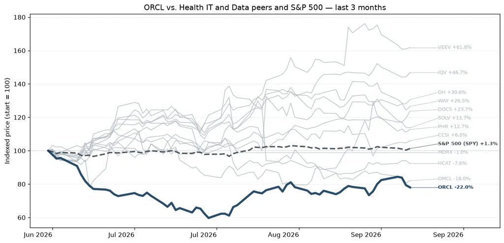

#### Earnings Call Summary

Oracle reported record Q1 2027 revenue of $19.3 billion, up 30% year-over-year, marking its first-ever sequential growth from Q4. Non-GAAP operating income rose 31% to $8.2 billion, maintaining a 42% operating margin, while non-GAAP EPS grew 30% to $1.92, driven by strong cloud infrastructure and application performance.

#### At a Glance

- **Oracle Beats Earnings and Revenue Estimates:** Oracle reported a top-line success for Q1 2027 with revenue of $19.35 billion against expectations of $19.13 billion, and delivered an adjusted EPS of $1.92, comfortably ahead of the $1.74 consensus estimate.
- **Cloud Infrastructure Revenue More Than Doubles:** Oracle Cloud Infrastructure (OCI) revenue surged 121% year-over-year to $7.4 billion, accelerating from the 93% growth seen in the previous quarter and underscoring massive demand for its AI computing capacity.
- **Full-Year Fiscal 2027 Forecast Upgraded:** Reflecting strong Q1 performance, Oracle raised its full-year fiscal 2027 revenue guidance to at least $90 billion and increased its full-year non-GAAP earnings projection to $8.10 per share.
- **Backlog Reaches Record $664 Billion:** Fueled by robust enterprise AI adoption, Oracle signed over $30 billion in new AI cloud contracts during the quarter, lifting its total remaining performance obligations to an all-time high of $664 billion.
- **Heavy Capital Spend Drives Negative Cash Flow:** Despite recording a historic $23 billion in operating cash flow, aggressive data center buildouts led to $28.5 billion in capital expenditures, leaving free cash flow negative at $5.4 billion.
- **Market Reaction Pushes Stock Higher:** Shares of Oracle jumped more than 6.9% in pre-market and extended trading as investors reacted favorably to the combination of AI-driven cloud growth and improved full-year financial targets.

#### Key Moments from the Call

- **19m 23s — Upgraded Full-Year Fiscal 2027 Guidance:** Oracle raised its full-year 2027 revenue outlook to at least $90 billion, representing 34% year-over-year growth, alongside an EPS target of $8.10. This aggressive upgrade underscores accelerating conversion of large RPO backlogs into current revenue and gives investors strong visibility into multi-quarter top-line expansion.
- **22m 19s — Innovative Funding Minimizes Cash CapEx:** Management clarified that $30 billion in new Q1 AI contracts will not drain Oracle's cash reserves due to prepayment structures and bring-your-own-hardware models. This strategy reassures investors concerned about liquidity, as it decouples hyper-scale infrastructure growth from direct corporate cash outlays during peak investment cycles.
- **25m 7s — Data Center Construction Timelines Secured:** Addressing market speculation regarding facility delays in New Mexico and Wisconsin, executives confirmed that data center delivery remains fully on track. Furthermore, they emphasized that Oracle's decentralized rollout strategy mitigates concentrated risks, ensuring these projects pose zero threat to the stated fiscal 2027 financial targets.
- **31m 10s — GPU Re-pricing Power Boosts Margins:** Oracle revealed that hardware capacity up for renewal during the quarter was successfully re-leased or resold at a 20% premium over prior contracts, despite the assets being four years or older. This data point highlights prolonged asset longevity and strong pricing power amid ongoing supply shortages.

## Company Overviews

### UnitedHealth (UNH)

*Payers · $380.1B · 3m -7.2% · 12m +7.5% · 24m -36.2%*

[Google Finance](https://www.google.com/finance/quote/UNH:NYSE?tab=earnings&hl=en)

Diversified healthcare company operating UHC insurance businesses and the Optum health services platform.

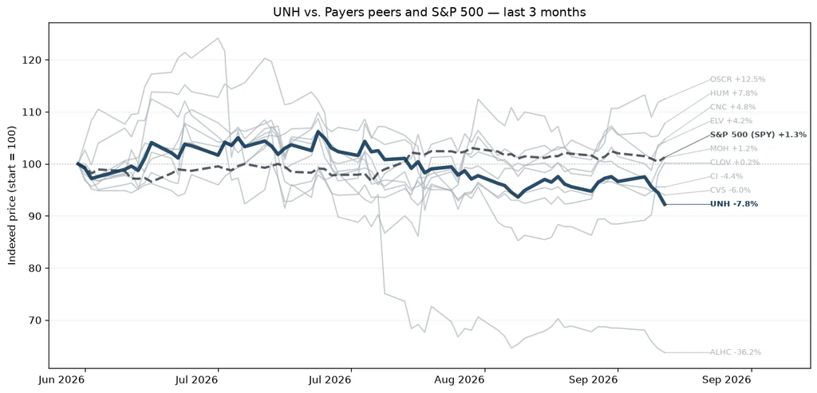

UnitedHealth Group is one of the largest private health insurers and provides medical benefits to about 51 million members globally, including 1 million outside the US as of December 2025. As a leader in employer-sponsored, self-directed, and government-backed insurance plans, UnitedHealth has obtained massive scale in medical insurance. Along with its insurance assets, UnitedHealth's Optum franchises help create a healthcare services colossus that spans everything from pharmaceutical benefits to providing outpatient care and analytics to affiliates and third parties.

### CVS Health (CVS)

*Payers · $135.1B · 3m -7.2% · 12m +26.2% · 24m +63.3%*

[Google Finance](https://www.google.com/finance/quote/CVS:NYSE?tab=earnings&hl=en)

Healthcare retail ecosystem.

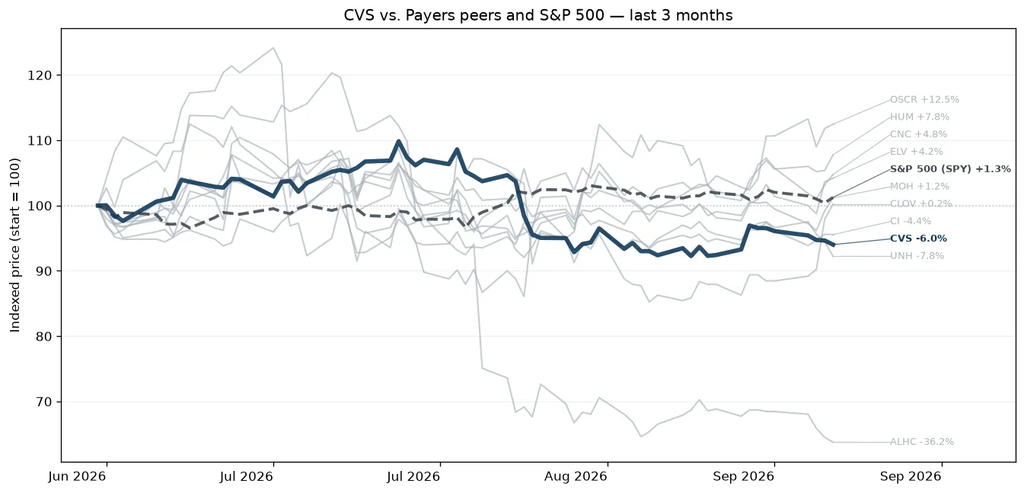

CVS Health offers a diverse set of healthcare services. Its roots are in its retail pharmacy operations, where it operates around 9,000 stores primarily in the US. CVS is also a large pharmacy benefit manager (acquired through Caremark), processing about 2 billion adjusted claims annually. It operates a top-tier health insurer (acquired through Aetna) through which it serves about 27 million medical members. The acquisition of Oak Street Health added primary care services to the mix, which could have significant synergies with all existing business lines.

### Humana (HUM)

*Payers · $43.7B · 3m +8.1% · 12m +48.2% · 24m +27.4%*

[Google Finance](https://www.google.com/finance/quote/HUM:NYSE?tab=earnings&hl=en)

Large payer, Medicare and Medicare Advantage focused.

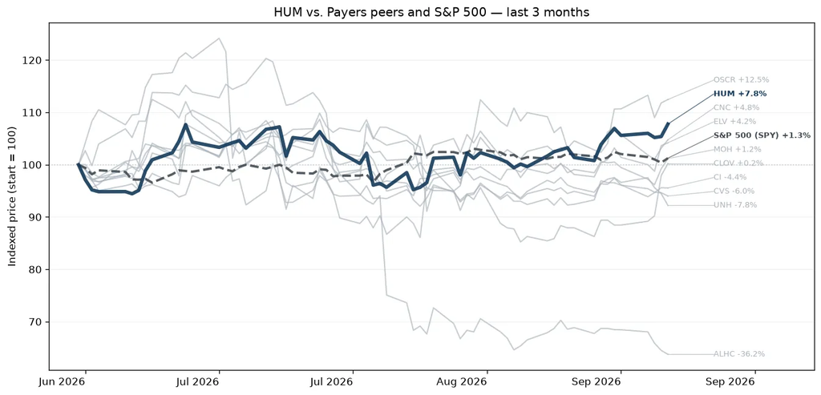

Humana is one of the largest private health insurers in the US, and the firm has built a niche specializing in government-sponsored programs, with nearly all its medical membership stemming from Medicare, Medicaid, and the military's Tricare program. Beyond medical insurance, the company provides other healthcare services, including primary-care services, at-home services, and pharmacy benefit management.

### Oscar Health (OSCR)

*Payers · $9.4B · 3m +16.0% · 12m +69.5% · 24m +51.6%*

[Google Finance](https://www.google.com/finance/quote/OSCR:NYSE?tab=earnings&hl=en)

Tech-focused payer with large exposure to exchange products and ICHRAs.

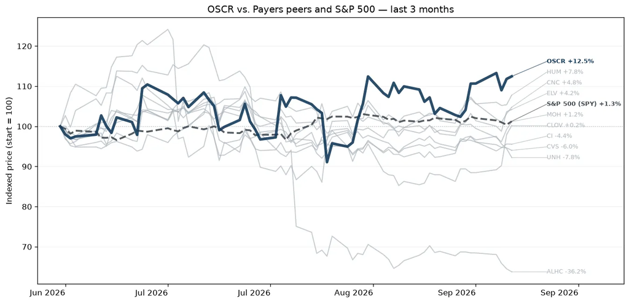

Oscar Health Inc is a healthcare technology company built around a full stack technology platform and a relentless focus on serving its members. It offers Individual & Family plans and health technology solutions that power the healthcare industry. Oscar operates as one segment to sell insurance to individuals, families and employees through the federal and state-run healthcare exchanges formed in conjunction with the Patient Protection and Affordable Care Act (ACA) and leverages its technology platform to provide services via its Oscar offering.

### Molina Healthcare (MOH)

*Payers · $10.2B · 3m +2.0% · 12m +12.9% · 24m -43.0%*

[Google Finance](https://www.google.com/finance/quote/MOH:NYSE?tab=earnings&hl=en)

Managed-care company providing health insurance through government programs.

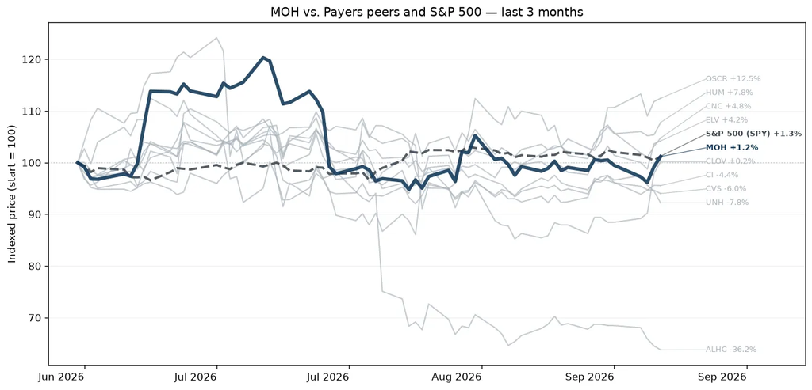

Molina Healthcare Inc provides medical insurance plans through Medicaid, the individual exchanges, and Medicare. The company operates in four reportable segments consisting of: 1) Medicaid; 2) Medicare; 3) Marketplace; and 4) Other. It manages health benefit risks for more than 5 million people, with more than 85% of those members coming through contracts with state governments for their Medicaid programs. Medicaid contracts in four states-California, New York, Texas, and Washington-account for over half of its enrollees.

### Cigna (CI)

*Payers · $73.7B · 3m -5.8% · 12m -7.3% · 24m -23.0%*

[Google Finance](https://www.google.com/finance/quote/CI:NYSE?tab=earnings&hl=en)

Employer-focused health insurance company.

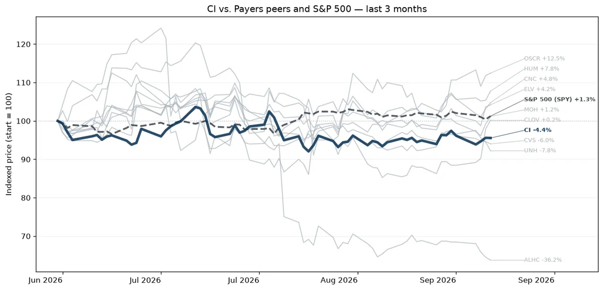

Cigna primarily provides pharmacy benefit management and health insurance services. Its PBM and specialty pharmacy services, which were greatly expanded by its 2018 merger with Express Scripts, are mostly sold to health insurance plans and employers. Its largest PBM contract is with the Department of Defense, and it recently won a multiyear deal with top-tier insurer Centene. In health insurance and other benefits, Cigna primarily serves employers through self-funding arrangements, and the company operates mostly in the US with 16 million US and 2 million international medical members covered as of December 2025.

### Elevance (ELV)

*Payers · $81.5B · 3m +3.6% · 12m +34.3% · 24m -24.0%*

[Google Finance](https://www.google.com/finance/quote/ELV:NYSE?tab=earnings&hl=en)

Health insurance company, previously named Anthem.

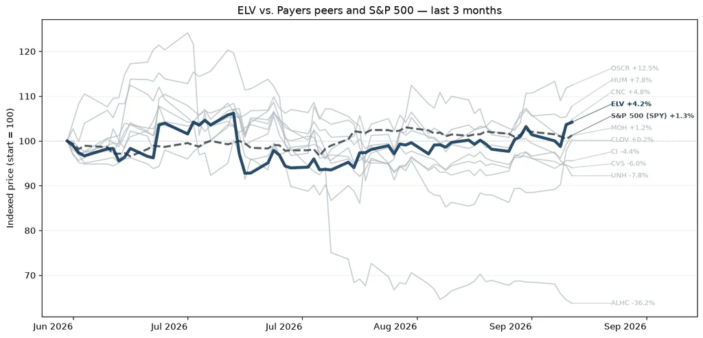

Elevance Health remains one of the leading health insurers in the US, providing medical benefits to 45 million medical members at the end of 2025. The company offers employer, individual, and government-sponsored coverage plans. Elevance differs from its peers in its unique position as the largest single provider of Blue Cross Blue Shield branded coverage, operating as the licensee for the Blue Cross Blue Shield Association in 14 states. Through acquisitions, such as the Amerigroup deal in 2012 and MMM in 2021, Elevance's reach expands beyond those states in government-sponsored programs, such as Medicaid and Medicare Advantage plans, too. It is also an emerging player in pharmacy benefit management and other healthcare services.

### Clover Health (CLOV)

*Payers · $2.2B · 3m +1.9% · 12m +57.5% · 24m +61.2%*

[Google Finance](https://www.google.com/finance/quote/CLOV:NASDAQ?tab=earnings&hl=en)

American healthcare company company providing Medicare Advantage insurance plans.

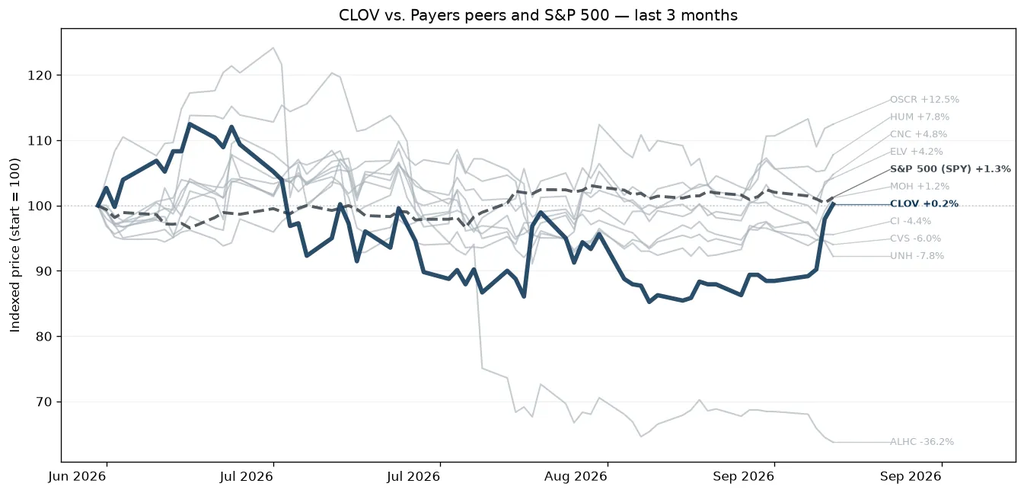

Clover Health Investments Corp is a healthcare technology company. It focuses on empowering Medicare physicians to proactively manage chronic diseases through its proprietary software platform, Clover Assistant. This cloud-based solution provides personalized insights to physicians, enabling early detection and management of chronic conditions. It operates in one segment: Insurance, through which it offers PPO and HMO plans to Medicare Advantage members in several states.

### Centene (CNC)

*Payers · $30.7B · 3m +1.9% · 12m +99.7% · 24m -11.9%*

[Google Finance](https://www.google.com/finance/quote/CNC:NYSE?tab=earnings&hl=en)

Health insurance for government and privately insured healthcare programs.

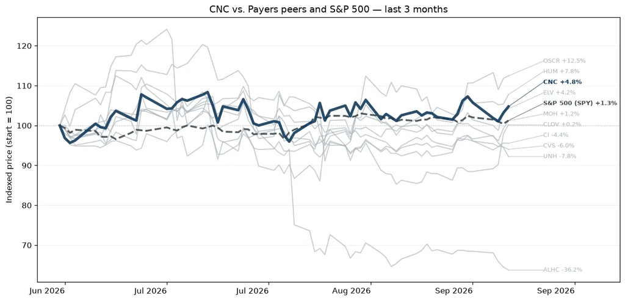

Centene is a managed care organization that focuses on government-sponsored healthcare plans, including Medicaid, Medicare, and the individual exchanges. Centene served 20 million medical members as of December 2025, mostly in Medicaid (about 64% of membership), the individual exchanges (about 28%), and Medicare (about 5%). The company also provides Medicare Part D pharmaceutical plans.

### Alignment Health (ALHC)

*Payers · $3.1B · 3m -36.2% · 12m -21.4% · 24m +6.1%*

[Google Finance](https://www.google.com/finance/quote/ALHC:NASDAQ?tab=earnings&hl=en)

Tech-enabled Medicare Advantage Company.

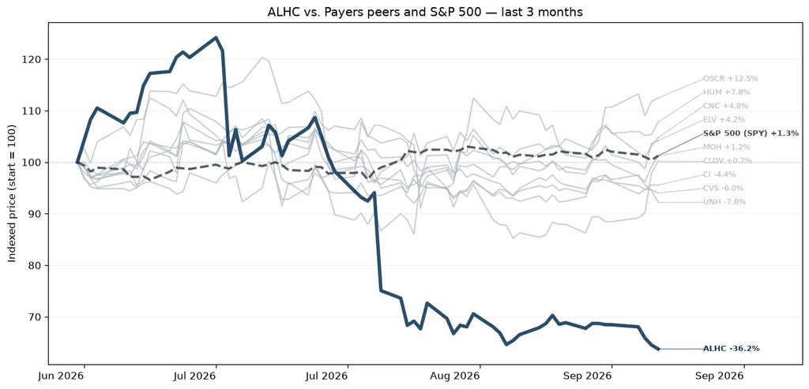

Alignment Healthcare Inc is a next-generation, consumer-centric platform that is revolutionizing the healthcare experience for seniors through Medicare Advantage plans. These plans are marketed and sold direct-to-consumer, allowing seniors to select the manner in which customers receive healthcare coverage and services on an annual basis. The company combines a technology platform and clinical model for more effective health outcomes.

### HCA Healthcare (HCA)

*Health System Providers · $87.2B · 3m +10.3% · 12m +5.4% · 24m +8.2%*

[Google Finance](https://www.google.com/finance/quote/HCA:NYSE?tab=earnings&hl=en)

Largest for-profit hospital and outpatient care operator in the United States.

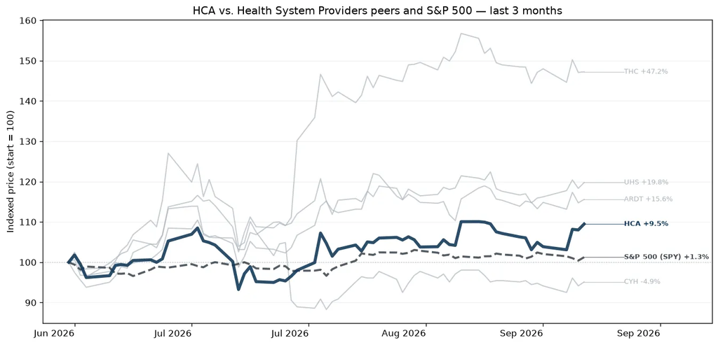

HCA Healthcare is a Nashville-based healthcare provider organization operating the largest collection of acute-care hospitals in the United States. As of December 2025, the firm owned and operated 190 hospitals and over 2,500 outpatient facillities across 19 states and a small foothold in the United Kingdom.

### Tenet Health (THC)

*Health System Providers · $20.5B · 3m +51.0% · 12m +36.8% · 24m +62.4%*

[Google Finance](https://www.google.com/finance/quote/THC:NYSE?tab=earnings&hl=en)

Diversified healthcare provider with hospitals and a leading ambulatory surgery center platform through USPI.

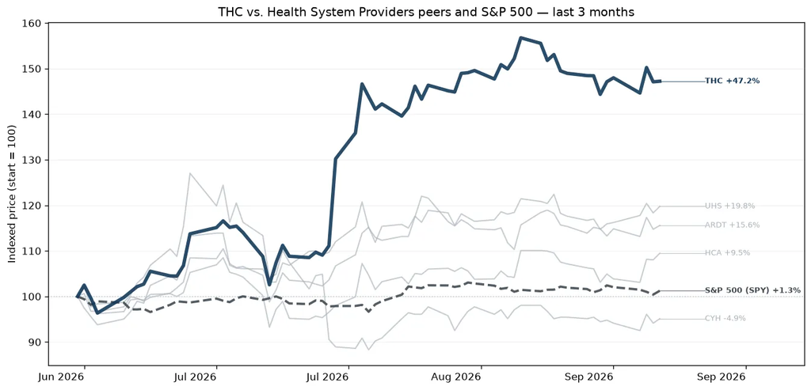

Tenet Healthcare is a Dallas-based healthcare services organization. It operates acute and specialty hospitals (50 as of December 2025) and hundreds of ambulatory surgery centers and other outpatient facilities across the US, primarily in the South. Through its Conifer segment, Tenet also provides revenue cycle management solutions.

### Universal Health Services (UHS)

*Health System Providers · $10.2B · 3m +19.4% · 12m -8.8% · 24m -24.8%*

[Google Finance](https://www.google.com/finance/quote/UHS:NYSE?tab=earnings&hl=en)

Hospital operator with significant acute care and behavioral health business.

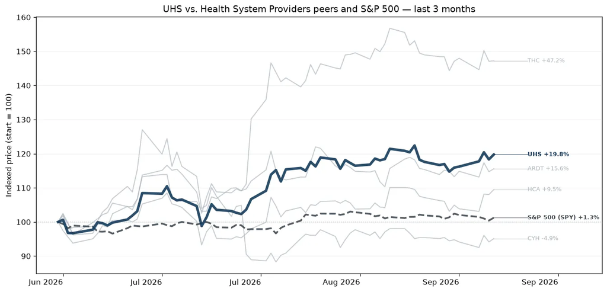

Universal Health Services Inc offers healthcare services through its behavioral health centers, acute care hospitals, and related outpatient facilities. As of late 2025, the company operated 346 inpatient behavioral health centers, 29 acute care hospitals, and many supportive outpatient facilities. Its operations are concentrated in the U.S, particularly in Nevada (21% of 2025 operating profits), Texas (19%), and California (13%), although it does have some exposure to the UK behavioral health market (6% of 2025 sales) too. While its acute care services account for over 55% of revenue, the behavioral health centers sport higher margins and account for over 55% of pretax profits.

### Community Health Systems (CYH)

*Health System Providers · $417.4M · 3m -6.4% · 12m -0.7% · 24m -49.0%*

[Google Finance](https://www.google.com/finance/quote/CYH:NYSE?tab=earnings&hl=en)

Operator of community hospitals primarily serving non-urban and regional markets.

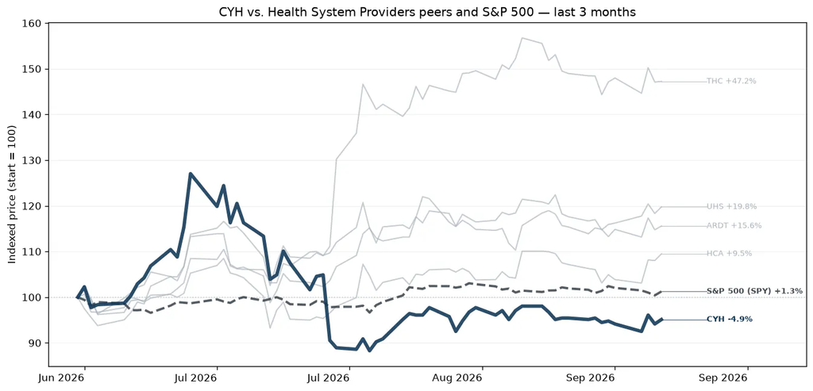

Community Health Systems Inc is a publicly owned hospital operator in the United States. The company also owns four home health agencies and provides management and consulting services to independent hospitals. The firm derives revenue through a broad range of general and specialized hospital healthcare services and outpatient services.

### Ardent Health Partners (ARDT)

*Health System Providers · $1.5B · 3m +17.4% · 12m -16.1% · 24m -39.5%*

[Google Finance](https://www.google.com/finance/quote/ARDT:NYSE?tab=earnings&hl=en)

Regional hospital operator focused on integrated health systems across mid-sized US markets.

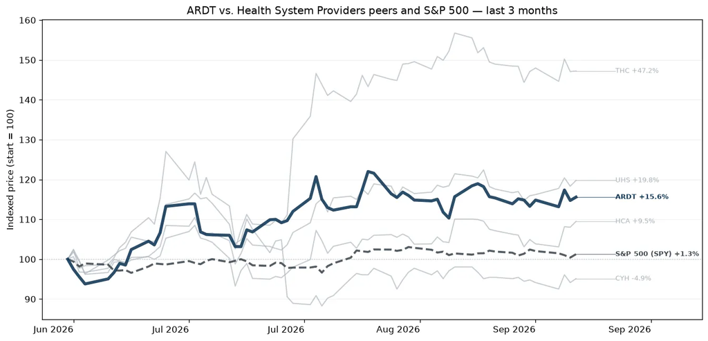

Ardent Health Inc is a provider of healthcare in growing mid-sized urban communities across the U.S and operating in eight growing mid-sized urban markets across six states Texas, Oklahoma, New Mexico, New Jersey, Idaho, and Kansas. The main focus on people and investments in services and technologies.

### The Ensign Group (ENSG)

*Inpatient Non-Acute Providers · $10.4B · 3m +16.5% · 12m +3.6% · 24m +13.9%*

[Google Finance](https://www.google.com/finance/quote/ENSG:NASDAQ?tab=earnings&hl=en)

Leading operator of skilled nursing facilities, rehabilitation centers, and senior-care services.

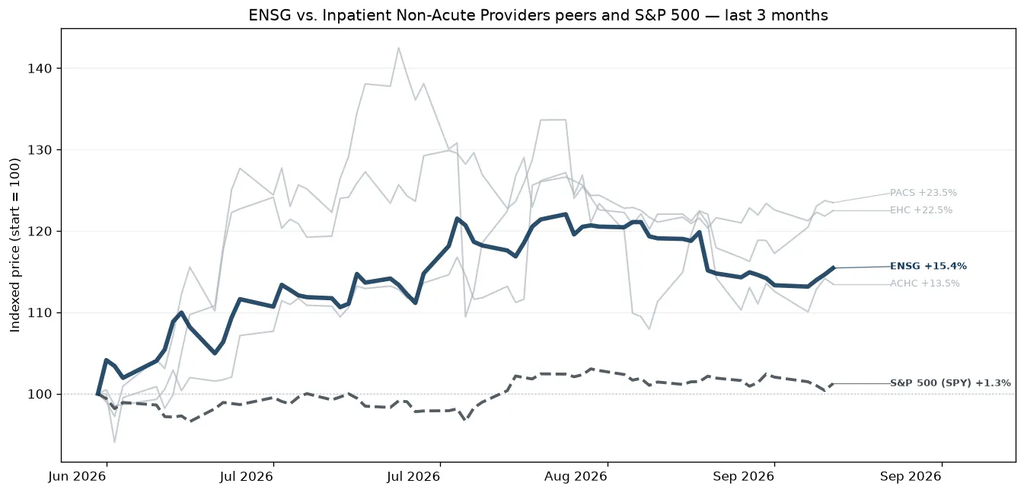

Ensign Group Inc provides post-acute healthcare services in the United States. Its regional subsidiaries oversee skilled nursing, assisted living, home health and hospice, mobile ancillary, and urgent care operations. Medicare and Medicaid programs contribute majority of revenue received for Ensign's services. The firm operates through two segments, Skilled services, and Standard Bearer. The skilled services segment includes the operation of skilled nursing facilities and rehabilitation therapy services. The Standard Bearer segment comprises of properties owned by the company through its captive REIT and leased to skilled nursing and assisted living operations. The majority of the revenue is generated from the skilled services segment.

### Acadia Healthcare (ACHC)

*Inpatient Non-Acute Providers · $2.8B · 3m +15.3% · 12m +30.5% · 24m -63.7%*

[Google Finance](https://www.google.com/finance/quote/ACHC:NASDAQ?tab=earnings&hl=en)

Largest provider of behavioral health and addiction treatment services.

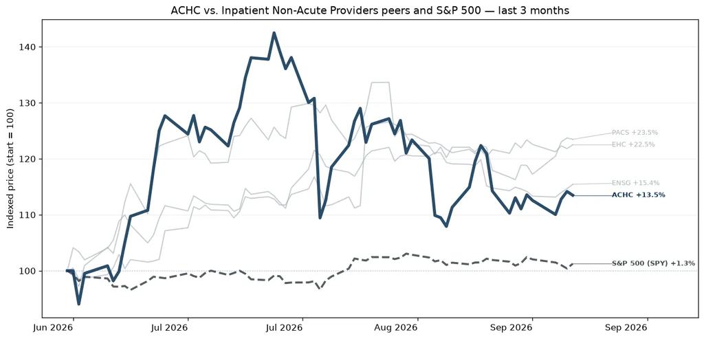

Acadia Healthcare Co Inc acquires and develops behavioral healthcare facilities. Its facilities and services are classified into the following categories: acute inpatient psychiatric facilities; specialty treatment facilities; CTCs; and residential treatment centers. In which Acute inpatient psychiatric facilities contribute the majority of revenue in the United States. The Company has one reportable segment, behavioral healthcare services. The behavioral healthcare services segment provides inpatient and outpatient behavioral healthcare services.

### Encompass Health (EHC)

*Inpatient Non-Acute Providers · $11.0B · 3m +19.9% · 12m -3.4% · 24m +30.5%*

[Google Finance](https://www.google.com/finance/quote/EHC:NYSE?tab=earnings&hl=en)

In-patient post-acute rehabilitation services.

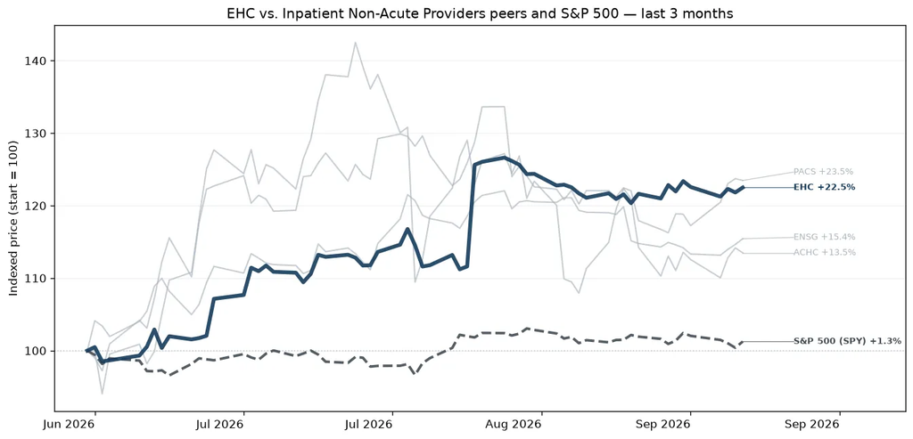

Encompass Health Corp provides post-acute healthcare services in the United States through a network of inpatient rehabilitation hospitals, which is the company's sole segment. Inpatient rehabilitation contributes the majority of the firm's revenue and provides specialized rehabilitative treatment through a network of inpatient hospitals. The company's inpatient rehabilitation hospitals provide a higher level of rehabilitative care to patients who are recovering from conditions such as stroke and other neurological disorders, cardiac and pulmonary conditions, brain and spinal cord injuries, complex orthopedic conditions, and amputations.

### PACS Group (PACS)

*Inpatient Non-Acute Providers · $7.3B · 3m +23.4% · 12m +359.1% · 24m +9.9%*

[Google Finance](https://www.google.com/finance/quote/PACS:NYSE?tab=earnings&hl=en)

Post-acute care and skilled nursing company.

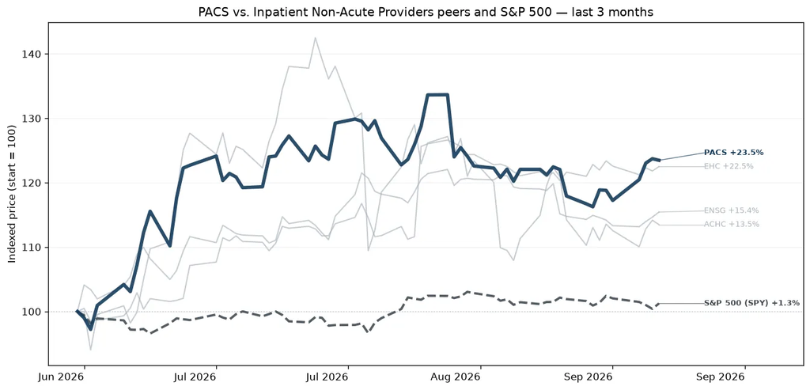

PACS Group Inc is a post-acute healthcare company mainly focused on delivering skilled nursing care through a portfolio of independently operated facilities. The post-acute care ecosystem serves individuals who need additional help recuperating from acute conditions, illnesses, or serious medical procedures after getting discharged from the hospital. It also provides senior care, assisted living, and independent living options in some of the communities. The company has one reportable segment.

### Healthpeak properties (DOC)

*Health Care Real Estate · $15.1B · 3m -1.9% · 12m +12.3% · 24m -10.1%*

[Google Finance](https://www.google.com/finance/quote/DOC:NYSE?tab=earnings&hl=en)

Healthcare industry real estate investment trust focused on outpatient medical offices, life science properties, an senior housing.

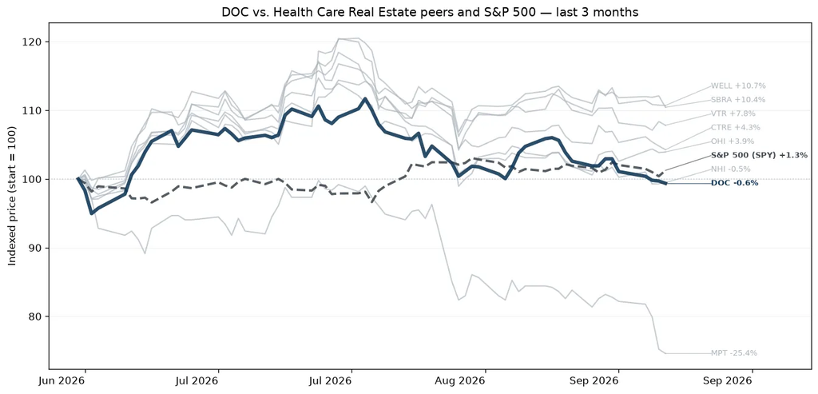

Healthpeak owns a diversified healthcare portfolio of approximately 700 in-place properties spread across mainly medical office and life science assets, plus a handful of senior housing, hospital, and skilled nursing/post-acute care assets, as well.

### Ventas, Inc (VTR)

*Health Care Real Estate · $48.0B · 3m +6.4% · 12m +29.1% · 24m +38.3%*

[Google Finance](https://www.google.com/finance/quote/VTR:NYSE?tab=earnings&hl=en)

Real estate investment trust focused on ownership and management of senior housing, research, medicine office buildings, and healthcare facilities.

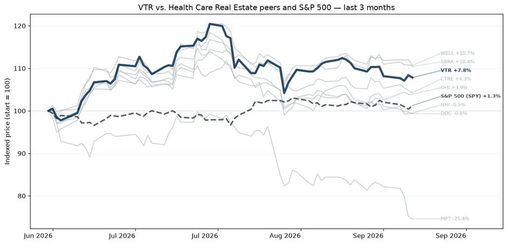

Ventas owns a diversified healthcare portfolio of almost 1,400 in-place properties spread across the senior housing, medical office, hospital, life science, and skilled nursing/post-acute care. The portfolio includes almost 100 properties in Canada and the United Kingdom as the company looks for additional investment opportunities in countries with mature healthcare systems that operate similarly to the United States. The firm also owns mortgages and other loans, contributing about 1% of net operating income.

### Medical Properties Trust (MPT)

*Health Care Real Estate · $2.8B · 3m -26.6% · 12m n/a · 24m n/a*

[Google Finance](https://www.google.com/finance/quote/MPT:NYSE?tab=earnings&hl=en)

Real estate investment trust for healthcare facilities in the US and Europe.

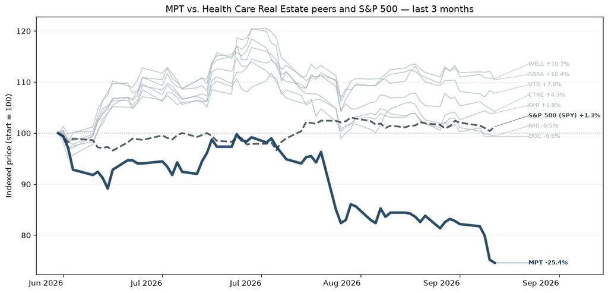

Medical Properties Trust Inc acquires and develops net-leased healthcare facilities. Its investments in healthcare real estate, other loans, and any investments in tenants are considered a single reportable segment. Its business strategy is to acquire and develop healthcare facilities and lease the facilities to healthcare operating companies under long-term net leases, which require the tenant to bear of the costs associated with the property. The group's geographic areas are the United States, the United Kingdom, and All other countries.

### National Health Investors (NHI)

*Health Care Real Estate · $3.7B · 3m -2.5% · 12m -10.2% · 24m -17.3%*

[Google Finance](https://www.google.com/finance/quote/NHI:NYSE?tab=earnings&hl=en)

Healthcare REIT focused on senior housing, skilled nursing, and long-term care properties.

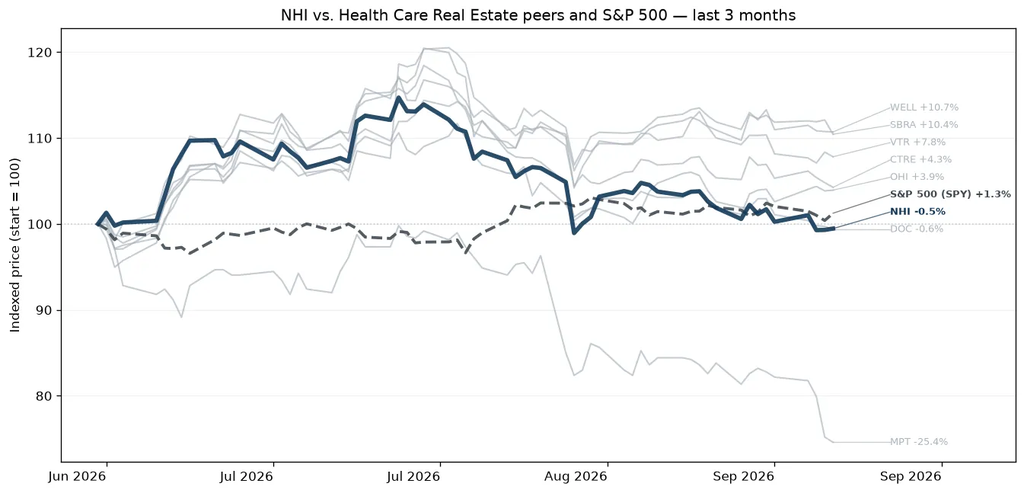

National Health Investors Inc is a self-managed REIT that owns, leases, operates, and finances the development of senior housing communities and medical facilities. It operates through two segments: Real Estate Investments and Senior Housing Operating Portfolio (SHOP). The Real Estate Investments segment, which generates the majority of revenue, includes real estate leases, mortgages, and other notes receivable related to independent living facilities, assisted living facilities, entrance fee communities, senior living campuses, skilled nursing facilities, and a hospital. The SHOP segment consists of ventures that own and operate independent living facilities. The company's revenues are derived from rental income, interest and other income, and resident fees and services.

### Omega Healthcare Investors (OHI)

*Health Care Real Estate · $15.1B · 3m +2.7% · 12m +10.6% · 24m +15.7%*

[Google Finance](https://www.google.com/finance/quote/OHI:NYSE?tab=earnings&hl=en)

Healthcare REIT healthcare REIT focused on skilled nursing and assisted living facilities.

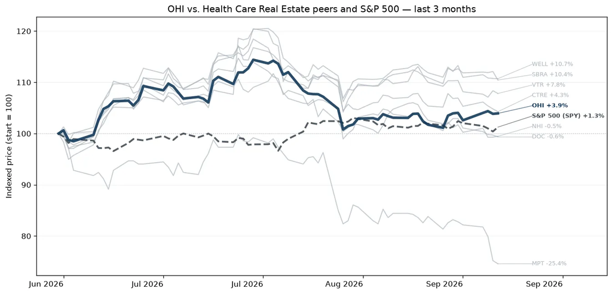

Omega Healthcare Investors Inc is a real estate investment trust that invests in healthcare-related real estate properties located in the United States (U.S.), the United Kingdom (U.K.), and Canada. The company's objective is to provide attractive returns to investors while serving as the preferred capital partner to its third-party healthcare operating companies and affiliates, as well as other third-party healthcare operators, allowing them to focus on delivering a high level of care to their resident patients. Omega's investment portfolio mainly consists of skilled nursing facilities, assisted living facilities (ALFs), including care homes in the U.K., independent living facilities, rehabilitation and acute care facilities, and continuing care retirement communities.

### Welltower (WELL)

*Health Care Real Estate · $166.9B · 3m +10.0% · 12m +39.3% · 24m +81.6%*

[Google Finance](https://www.google.com/finance/quote/WELL:NYSE?tab=earnings&hl=en)

Largest healthcare REIT, focused on senior housing, outpatient medical, and wellness-oriented healthcare properties.

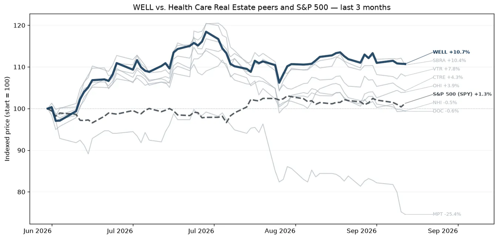

Welltower owns a diversified healthcare portfolio of 2,800 in-place properties spread across the senior housing, medical office, and skilled nursing/postacute care sectors. The portfolio includes over 900 properties in Canada and the United Kingdom as the company looks for additional investment opportunities in countries with mature healthcare systems that operate similarly to that of the United States.

### CareTrust REIT (CTRE)

*Health Care Real Estate · $9.6B · 3m +4.8% · 12m +12.9% · 24m +24.3%*

[Google Finance](https://www.google.com/finance/quote/CTRE:NYSE?tab=earnings&hl=en)

Healthcare REIT focused on skilled nursing, senior housing, and other post-acute care facilities.

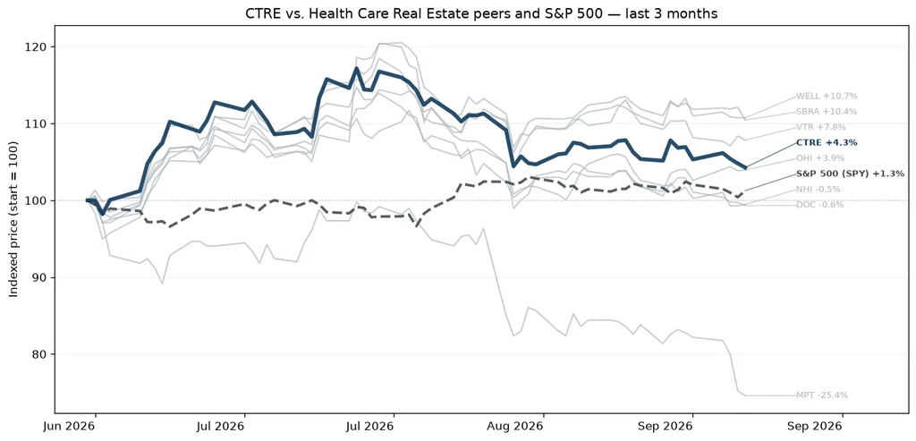

CareTrust REIT Inc is a self-administered, publicly traded REIT engaged in the ownership, acquisition, financing, development, and leasing of skilled nursing, seniors housing, and other healthcare-related properties. The company has one reportable segment consisting of investments in healthcare-related real estate assets. It generates revenues by leasing healthcare-related properties to healthcare operators under triple-net lease arrangements, in which the tenant is solely responsible for property-related costs. The company operates in Domestic and Foreign markets, with the majority of revenue coming from Domestic operations.

### Sabra Health Care REIT (SBRA)

*Health Care Real Estate · $5.3B · 3m +9.6% · 12m +7.7% · 24m +10.4%*

[Google Finance](https://www.google.com/finance/quote/SBRA:NASDAQ?tab=earnings&hl=en)

healthcare REIT focused on skilled nursing, senior housing, and behavioral health properties.

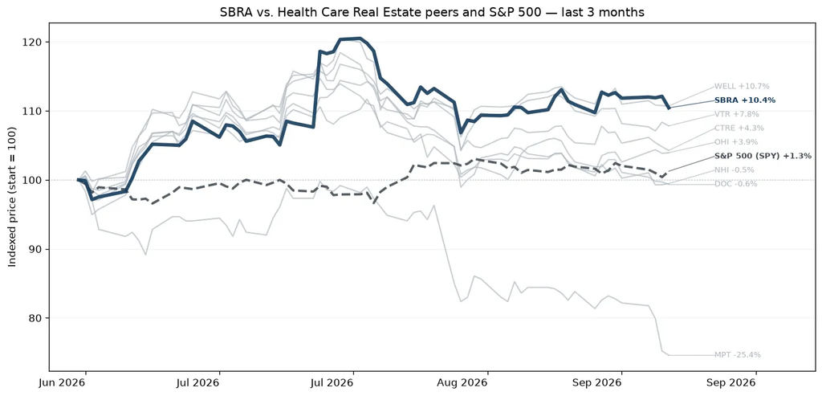

Sabra Health Care REIT Inc is a healthcare facility real estate investment trust. The company operates one segment that owns and invests in healthcare real estate. All of the company's revenue is generated in the United States. Sabra's operations consist of nursing facilities, assisted living centers, and mental health facilities.